# trace

2022-12-14

# Issue

First and foremost, this is all with reference to the Individual differences in online spoken word recognition: implications for sli paper (2010). My goal is to recreate the estimated fixation probabilities from the TRACE simulation, and then ultimately compare that with the empirical data using both looks and saccades.

The issue that I am having arises from Appendix C, where we are trying to go from TRACE activations to response probabilities. This involves:

1. Luce choice rule
2. Scaling with logistic
3. Adjusting time

I believe that the issue that I am having involves the scaling term. Specifically, I am wondering about the skew parameter being $w = 0.0001$; after I adjust using the luce choice rule in (1), the scaling factor ends up being either 0 or 1 (though this also happens if I don’t do luce choice rule). The issue to me it seems is that this scaling term moves very quicly from 0 to 1

Here i just want to briefly show what i did leading up to this in case there is something to be corrected sooner.

## Preprocessing

The data here is the data that was put in my directory in the rdss drive. It includes

1. Subject look data, restricted to the $N = 40$ TD subjects. Fixation probabilities were computed for each subject, though even in the TD group, some of the target/logistic curves look questionable. The subject look data looks like this:

```
##        subject time    target     cohort  unrelated      rhyme
##     1:      30    0 0.0000000 0.00000000 0.00000000 0.00000000
##     2:      30    4 0.0000000 0.00000000 0.00000000 0.00000000
##     3:      30    8 0.0000000 0.00000000 0.00000000 0.00000000
##     4:      30   12 0.0000000 0.00000000 0.00000000 0.00000000
##     5:      30   16 0.0000000 0.00000000 0.00000000 0.00000000
##    ---
## 42859:     121 1672 0.8636364 0.02097902 0.02797203 0.01048951
## 42860:     121 1676 0.8636364 0.02097902 0.02797203 0.01048951
## 42861:     121 1680 0.8636364 0.02097902 0.02797203 0.01048951
## 42862:     121 1684 0.8636364 0.02097902 0.02797203 0.01048951
## 42863:     121 1688 0.8636364 0.02097902 0.02797203 0.01048951
```

2. TRACE data from same directory. I computed the average activation across trials (I’m assuming this is correct). The TRACE data, processed, looks like this (frame to time adjustment already made):

```
##          target     cohort       rhyme         ur time
##   1: -0.0100000 -0.0100000 -0.01000000 -0.0100000   75
##   2: -0.0100000 -0.0100000 -0.01000000 -0.0100000   91
##   3: -0.0100000 -0.0100000 -0.01000000 -0.0100000  107
##   4: -0.0100000 -0.0100000 -0.01000000 -0.0100000  123
##   5: -0.0100000 -0.0100000 -0.01000000 -0.0100000  139
##  ---
## 104:  0.6055109 -0.1358403 -0.07842068 -0.1686970 1723
## 105:  0.6041609 -0.1358699 -0.07833389 -0.1683214 1739
## 106:  0.6026840 -0.1360157 -0.07821776 -0.1678741 1755
## 107:  0.6012282 -0.1360079 -0.07817638 -0.1676184 1771
## 108:  0.5997988 -0.1359167 -0.07811812 -0.1673954 1787
```

## Data without further manipulation

Here, I just want to show what each of the curves do look like when plotted

TRACE looks like I expect that it would

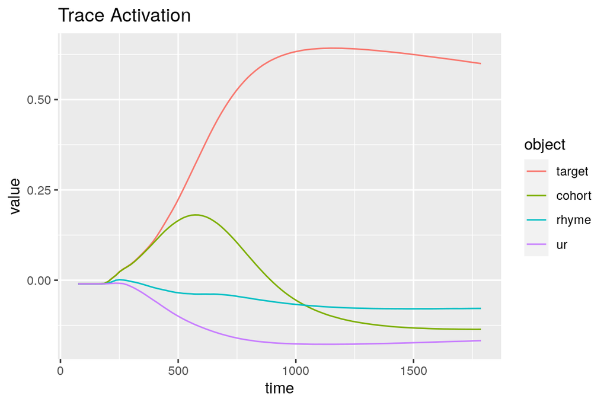

But here we have the target fixation probabilities for the TD children. Some of these have peak proportions much lower than I would have antiicpated. Is this correct?

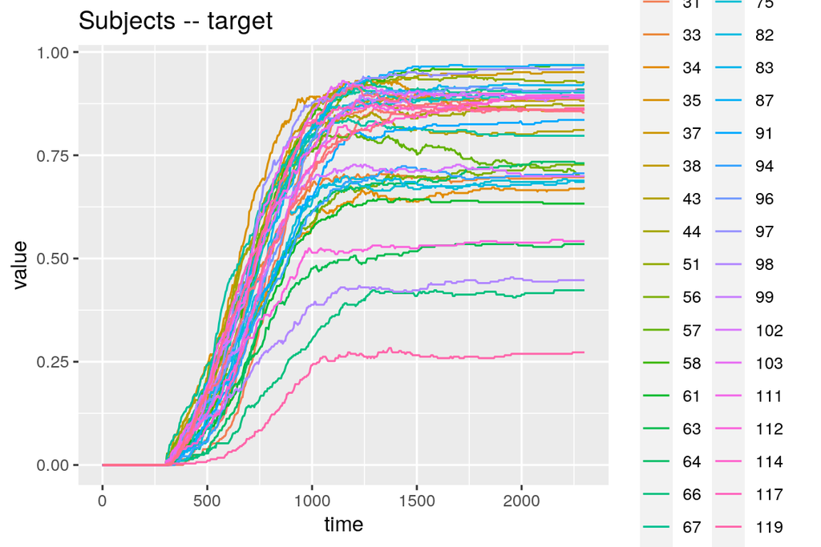

## Luce choice rule

This was implmented as a simple function in R

```r
## Using tau of 3, between baseline of 2.5 and max of 4
lucer <- function(l, tau = 3) {
  expl <- lapply(l, function(x) {
    exp(tau * x)
  })
  ss <- Reduce(`+`, expl)
  rr <- lapply(expl, function(x) as.data.table(x / ss))
  rr
}
l <- as.list(trace[, -"time", with = FALSE])
trace_luce <- Reduce(`cbind`, (lucer(l)))
names(trace_luce) <- names(l)
trace_luce <- cbind(trace[, .(time)], trace_luce)

# Looks accurate
trace_luce
```

```
##      time    target     cohort      rhyme         ur
##   1:   75 0.2500000 0.25000000 0.25000000 0.25000000
##   2:   91 0.2500000 0.25000000 0.25000000 0.25000000
##   3:  107 0.2500000 0.25000000 0.25000000 0.25000000
##   4:  123 0.2500000 0.25000000 0.25000000 0.25000000
##   5:  139 0.2500000 0.25000000 0.25000000 0.25000000
##  ---
## 104: 1723 0.7492377 0.08104486 0.09628010 0.07343736
## 105: 1739 0.7484005 0.08127560 0.09658793 0.07373600
## 106: 1755 0.7474924 0.08150180 0.09693290 0.07407291
## 107: 1771 0.7466142 0.08176426 0.09725485 0.07436673
## 108: 1787 0.7457354 0.08204141 0.09757487 0.07464832
```

## Scaling

The adjustment from the paper has the following scaling function:

$$\text{SCALING} = \frac{p-b}{1 + w \cdot \exp (-s \cdot (c -
\text{act}_{\text{max}}))^{1/w}} + b$$

This is where I feel less confident. Again, we use a simple function in R to find the maximum activation across each time point. According to the appendix, set values for this were

- p = 1
- b = 0
- w = 0.0001
- s = 4
- c = 0.25

```r
scaler <- function(a) { #a is max activation
  s <- 4
  w <- 0.0001
  cc <- 0.25
  den <- 1 + w * exp(-s * (cc - a))^(1/w)
  (ss <- 1/den)
}


## Find maximum activation at each time
trace_luce[, maxact := max(target, cohort, rhyme, ur), by = time]

trace_copy <- copy(trace_luce)

## Get scale term
trace_luce[, scaler_term := scaler(maxact)]

## These are basically all zero
summary(trace_luce$scaler_term)
```

```
##    Min. 1st Qu.  Median    Mean 3rd Qu.    Max.
## 0.00000 0.00000 0.00000 0.06481 0.00000 0.99990
```

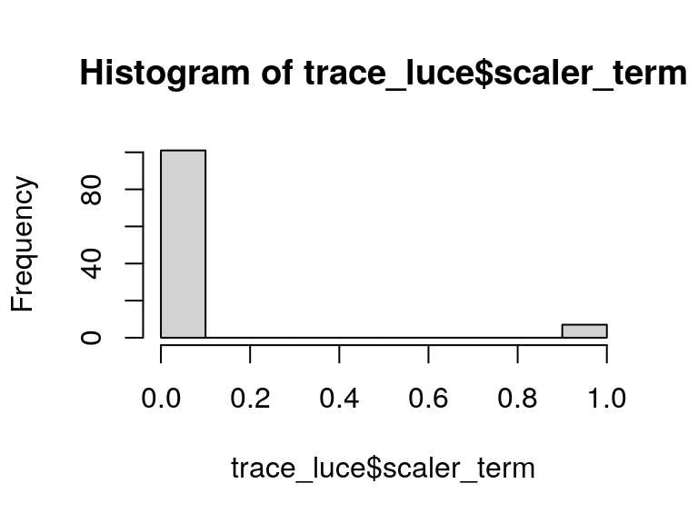

```r
hist(trace_luce$scaler_term)
```

This also seems backwards, as we are scaling the time at onset (where probability to each is 0.25) as nearly 1, where I would think this should be zero. At any rate, we can scale each of these and compare the plots

```r
trace_scale <- copy(trace_luce)
trace_scale[, `:=`(target = target * scaler_term,
                   cohort = cohort * scaler_term,
                   rhyme = rhyme * scaler_term,
                   ur = ur  * scaler_term)]

## These look wrong
head(trace_scale)
```

```
##    time    target    cohort     rhyme       ur    maxact scaler_term
## 1:   75 0.2499750 0.2499750 0.2499750 0.249975 0.2500000   0.9999000
## 2:   91 0.2499750 0.2499750 0.2499750 0.249975 0.2500000   0.9999000
## 3:  107 0.2499750 0.2499750 0.2499750 0.249975 0.2500000   0.9999000
## 4:  123 0.2499750 0.2499750 0.2499750 0.249975 0.2500000   0.9999000
## 5:  139 0.2499750 0.2499750 0.2499750 0.249975 0.2500000   0.9999000
## 6:  155 0.2499748 0.2499747 0.2499748 0.249975 0.2500002   0.9998993
```

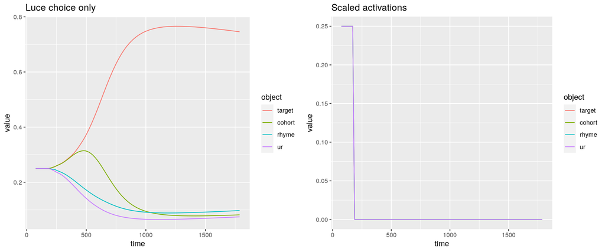

Clearly the luce choice only isn’t correct, as it has all of the proportions beginning at 0.25, but then after multiplying by the scaling term they appear to be total nonsense.

As I mentioned, I suspect it has to do with how quickly the scaling term goes from 0 (removing all activation) to 1 (which doesn’t scale anything)

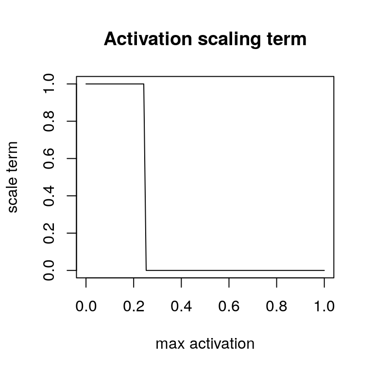

Things seem better when I set the scaling term to $w=1$, but it looks like it still scales things monotonically in the wrong direction. That is, instead of having activations near zero at onset, it appears as if it pushes activations to zero when response probabability is near one

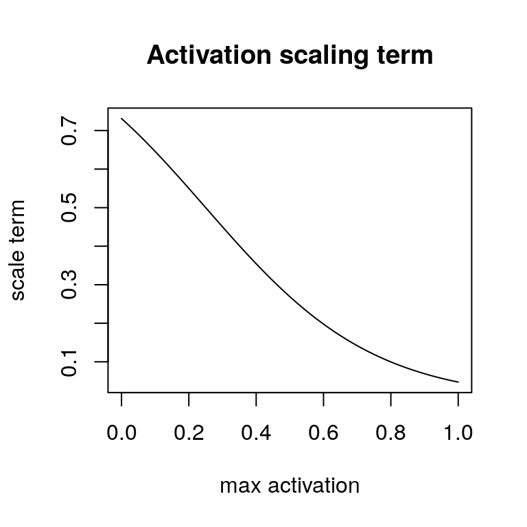

## Try with new scaler

Changes include

```r
scaler2 <- function(a, b = 0, p = 1) { #a is max activation
  s <- 4
  w <- 0.0001
  cc <- 0.25
  den <- (1 + w * exp(-s * (a - cc)))^(1/w)
  (ss <- (p-b)/den + b)
}

## Find maximum activation at each time
trace_luce <- copy(trace_copy)
trace_luce[, maxact := max(target, cohort, rhyme, ur), by = time]

## Get scale term
trace_luce[, scaler_target:= scaler2(maxact, min(target), max(target))]

im <- which.max(trace_luce$target)
imm <- which.min(trace_luce$target)

trace_luce[c(imm, im), .(target,  maxact, scaler_target)]
```

```
##       target    maxact scaler_target
## 1: 0.2500000 0.2500002     0.4397462
## 2: 0.7657575 0.7657575     0.7042143
```

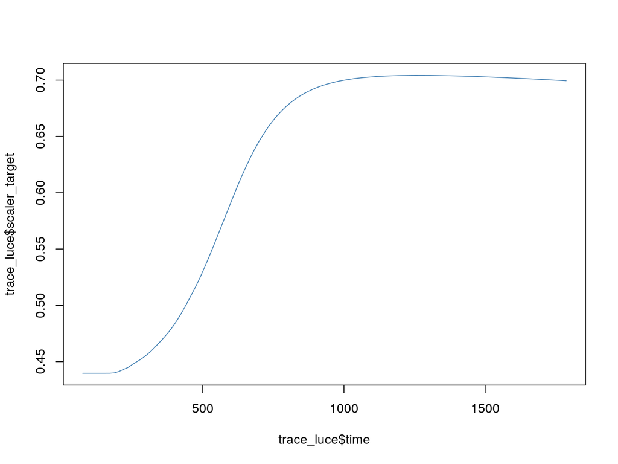

```r
plot(trace_luce$time, trace_luce$scaler_target, type = 'l', col = 'steelblue')
```

## Try without luce choice rule

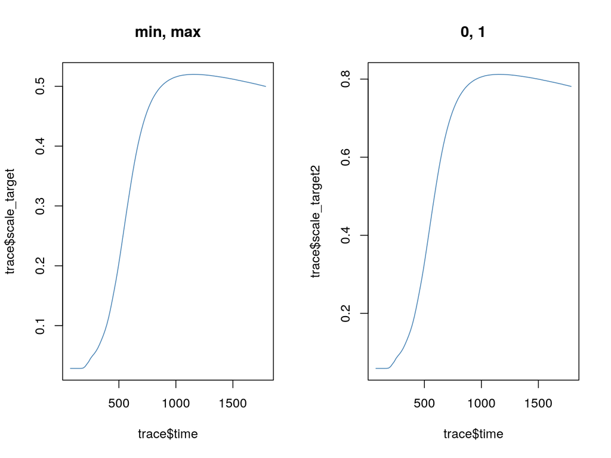

```r
trace[, maxact := max(target, cohort, rhyme, ur), by = time]
trace[,  scale_target := scaler2(maxact, min(target), max(target))]
trace[,  scale_target2 := scaler2(maxact, 0, 1)]

par(mfrow = c(1, 2))
plot(trace$time, trace$scale_target, type = 'l', col = 'steelblue', main = "min, max")
plot(trace$time, trace$scale_target2, type = 'l', col = 'steelblue', main = "0, 1")
```

## Questions

Based on the above, I have a few questions:

1. Is it correct to find the average activation for TRACE across each of the included simulations? If so, should I scale the activations before or after computing this average
2. There is clearly something wrong with my scaling function, but I’m not sure what (I know, this isn’t a question)
3. When I do go about trying to reconcile the relationship between TRACE, curve estimates based on looks and curve estimates based on saccades, should I do anything at all about the collection of subjects with fixation proportions below 0.5?